# 2015 Nike Golf Catalog

### Synopsis

The golf dataset has been subsetted from the **[2015 Nike Golf Catalog](http://www.printzandpatternz.com/2015NikeGolfCatalog.pdf)** consisting of polos, caps, outerwear, and bags. There are twenty-three polos from the ‘stripes’, ‘color pop’, and ‘textures’ categories using three attributes in the dataset:

- style
- description
- price

### Data Exploration

- dimensions
- names
- structure
- attributes
- data

Dimensions returns the lengths of rows and columns respectively. This dataset has twenty-three rows and three columns.

```
## [1] 23  3
```

Names returns the name(s) associated with an element of a vector. This dataset has three names.

```
## [1] "style"       "description" "price"
```

Structure returns the structure or reasonable output of an arbitrary object. This dataset’s structure is compactly displayed.

```
## 'data.frame':    23 obs. of  3 variables:
##  $ style      : int  677786 429439 429461 429438 578677 578678 244620 632418 527807 319966 ...
##  $ description: Factor w/ 23 levels "Dri-FIT Classic Tipped Polo",..: 5 16 21 15 13 20 14 4 6 1 ...
##  $ price      : num  60 88 88 86 66 ...
```

Attributes returns an object’s attributes. This dataset’s attributes include the names of rows, names of columns, and class.

```
## $names
## [1] "style"       "description" "price"
##
## $class
## [1] "data.frame"
##
## $row.names
##  [1]  1  2  3  4  5  6  7  8  9 10 11 12 13 14 15 16 17 18 19 20 21 22 23
```

Data returns the data matrix. This data matrix is the dataset used for this analysis.

```
##     style                                        description price
## 1  677786                           Dri-FIT Fade Stripe Polo 59.98
## 2  429439           Elite Series Dri-FIT Ottoman Bonded Polo 87.98
## 3  429461    Ladies Elite Series Dri-FIT Ottoman Bonded Polo 87.98
## 4  429438 Elite Series Dri-FIT Heather Fine Line Bonded Polo 85.98
## 5  578677                           Dri-FIT Tech Stripe Polo 65.98
## 6  578678                    Ladies Dri-FIT Tech Stripe Polo 65.98
## 7  244620                              Dri-FIT Textured Polo 55.98
## 8  632418                       Dri-FIT Engineered Mesh Polo 59.98
## 9  527807                               Dri-FIT Graphic Polo 67.98
## 10 319966                        Dri-FIT Classic Tipped Polo 47.98
## 11 527806                      Dri-FIT Sport Colorblock Polo 63.98
## 12 402394                       Dri-FIT Shoulder Stripe Polo 43.98
## 13 474237                                   Dri-FIT N98 Polo 57.98
## 14 474238                            Ladies Dri-FIT N98 Polo 57.98
## 15 443119                    Dri-FIT Sport Swoosh Pique Polo 57.98
## 16 452885             Ladies Dri-FIT Sport Swoosh Pique Polo 57.98
## 17 354055                       Nike Sphere Dry Diamond Polo 69.98
## 18 358890                Ladies Nike Sphere Dry Diamond Polo 69.98
## 19 632412                              Dri-FIT Embossed Polo 65.98
## 20 349899                    Dri-FIT Cross-Over Texture Polo 59.98
## 21 474231                               Dri-FIT Heather Polo 55.98
## 22 474455                        Ladies Dri-FIT Heather Polo 55.98
## 23 378453                          Dri-FIT Mini Texture Polo 43.98
```

### Explore Individual Variables

- summary
- quantile

Summary returns the result summaries of various model fitting functions. This dataset summary includes quantitative and qualitative information.

```
##      style                                 description     price
##  Min.   :244620   Dri-FIT Classic Tipped Polo    : 1   Min.   :43.98
##  1st Qu.:390424   Dri-FIT Cross-Over Texture Polo: 1   1st Qu.:56.98
##  Median :452885   Dri-FIT Embossed Polo          : 1   Median :59.98
##  Mean   :462842   Dri-FIT Engineered Mesh Polo   : 1   Mean   :62.94
##  3rd Qu.:527807   Dri-FIT Fade Stripe Polo       : 1   3rd Qu.:66.98
##  Max.   :677786   Dri-FIT Graphic Polo           : 1   Max.   :87.98
##                   (Other)                        :17
```

Quantile returns the sample quantiles corresponding to the given probabilities. This dataset’s quantile produces numeric information.

```
##    0%   25%   50%   75%  100%
## 43.98 56.98 59.98 66.98 87.98
```

### Plots

- density plot
- heatmap

#### Density Plot

Density Plot returns the distribution of a variable.Notice how the average polo price is around sixty dollars.

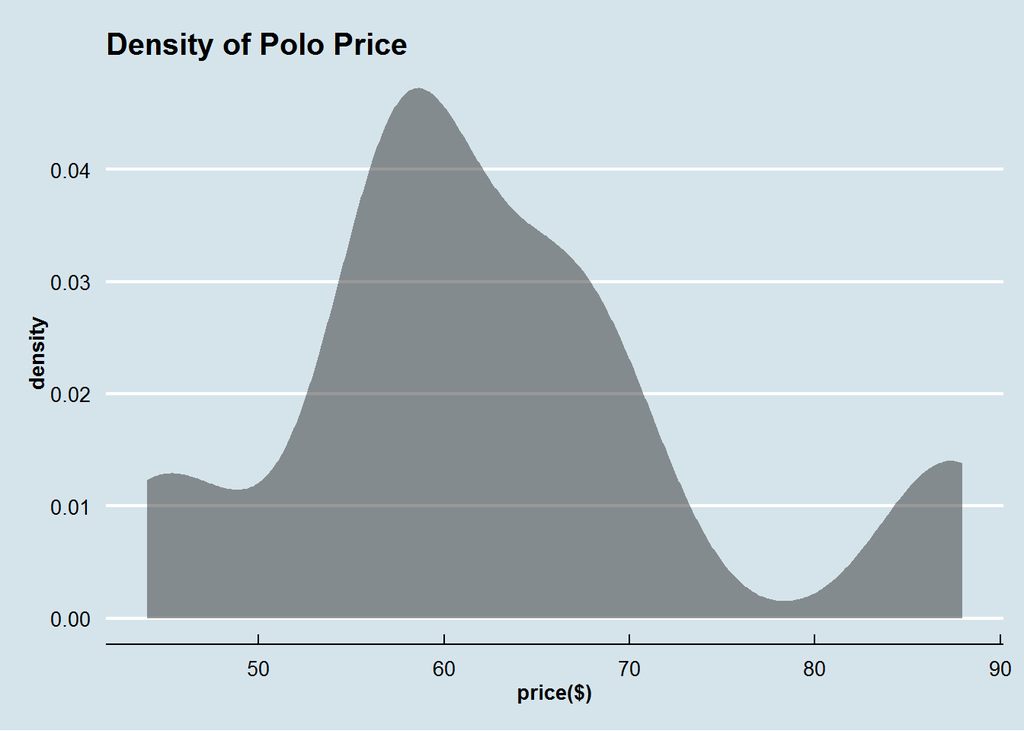

#### Heatmap

Heatmap returns a 2D display of a data matrix and calculates the similarity between data. For instance, notice how styles 429438, 429439, and 429461 are clustered together according to like pricing and all happen to be in the stripes category.

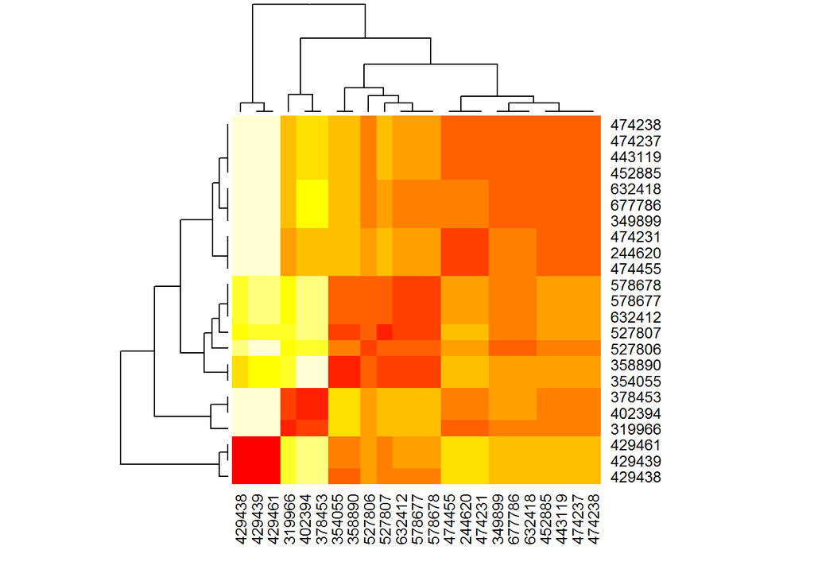